# Lego Assembly Thesis Analysis

# STASH

## JAR-LEVEL ANALYSIS

At the JAR level, each participant contributes two rows, to the df_tasks dataframe. - PID is a random effect - FORMAT is within-subject - JAR is within subject (confounded with ORDER) - ORDER is between subjects

## STEP-LEVEL ANALYSIS

At the STEP level, each participant contributes 2 x (number of steps in a jar) data points; analysis with the `df_joined_steps_errors` dataframe. - PID is a random effect - STEP is nested within JAR

## STEPS

### STEP COUNT

#### DESCRIBE participant-level

```r
## SET DATAFRAME
df <- df_steps_count

## PRINT TABLE OF STEP COUNTS PER PARTICIPANT-JAR
title = "Number of steps per JAR per PARTICIPANT"
subtitle = "(includes repeated steps)"
(t <- table(df$PID, df$JAR) %>%
  addmargins() %>%
  kbl(caption = title) %>%
  kable_classic())
```

Number of steps per JAR per PARTICIPANT

|  | jar1 | jar2 | Sum |
| --- | --- | --- | --- |
| P01 | 32 | 44 | 76 |
| P02 | 34 | 31 | 65 |
| P03 | 35 | 33 | 68 |
| P04 | 35 | 55 | 90 |
| P05 | 30 | 30 | 60 |
| P06 | 32 | 30 | 62 |
| P07 | 30 | 30 | 60 |
| P08 | 30 | 30 | 60 |
| P09 | 30 | 32 | 62 |
| P10 | 33 | 34 | 67 |
| P12 | 34 | 30 | 64 |
| P13 | 34 | 35 | 69 |
| P14 | 57 | 40 | 97 |
| P15 | 34 | 32 | 66 |
| P16 | 36 | 30 | 66 |
| P17 | 32 | 34 | 66 |
| Sum | 548 | 550 | 1098 |

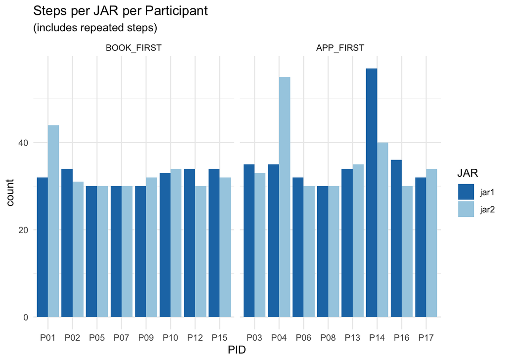

```r
## GROUPED BARCHART [COUNT STEPS X PARTICIPANT by JAR]
df %>%
  ggplot(aes(x=PID, fill=JAR))+
    geom_bar(position="dodge") +
  facet_wrap(~ORDER, scales = "free_x") +
  scale_fill_brewer(palette="Paired", direction =-1) +
  theme_minimal() +
  labs(title = "Steps per JAR per Participant",
       subtitle = "(includes repeated steps)")
```

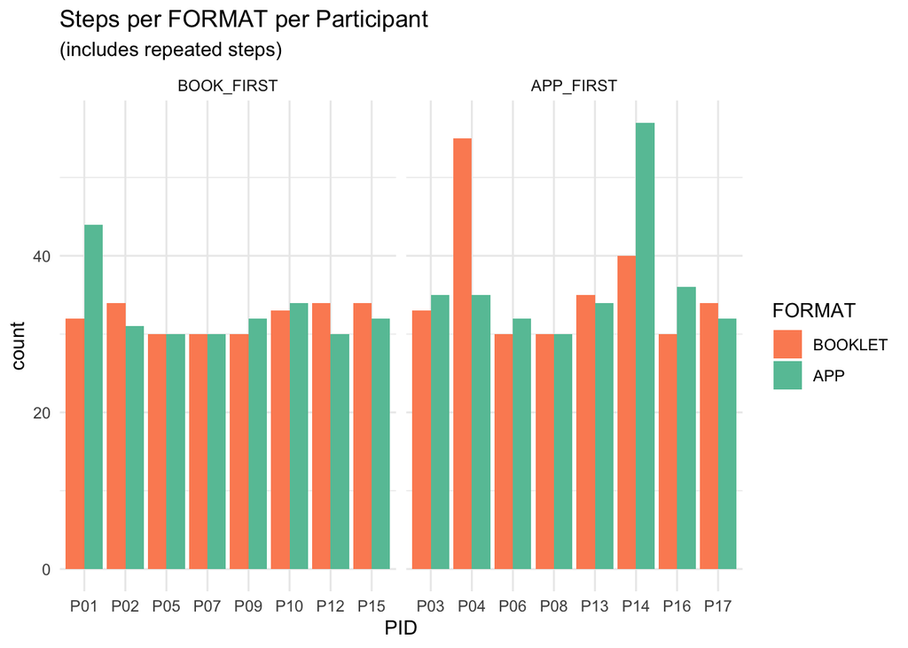

```r
## GROUPED BARCHART [COUNT STEPS X PARTICIPANT by FORMAT]
df %>%
  ggplot(aes(x=PID, fill=FORMAT))+
    geom_bar(position="dodge") +
   facet_wrap(~ORDER, scales = "free_x") +
      scale_fill_brewer(palette="Set2", direction =-1) +
  theme_minimal() +
  labs(title = "Steps per FORMAT per Participant",
       subtitle = "(includes repeated steps)")
```

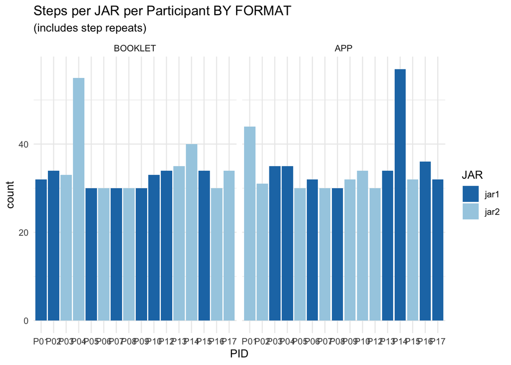

```r
## GROUPED BARCHART [COUNT STEPS X PARTICIPANT by JAR facet FORMAT]
g <- df %>%
  ggplot(aes(x=PID, fill=JAR))+
    geom_bar(position="dodge") +
  scale_fill_brewer(palette="Paired", direction =-1) +
  facet_wrap(~FORMAT) +
  theme_minimal() +
  labs(title = "Steps per JAR per Participant BY FORMAT",
       subtitle = "(includes step repeats)")


g
```

```r
ggsave(
  filename = "figs/step_counts_by_format.svg",
  plot = g,
  device = svglite,
  width = 6,
  height = 4,
  units = "in"
)
```

#### DESCRIBE jar-level

```r
## SET DATAFRAME
df <- df_steps_count

## PRINT TABLE OF STEP COUNTS PER PARTICIPANT-JAR
title = "Number of steps per JAR per FORMAT"
subtitle = "(includes repeated steps)"
(t <- table(df$FORMAT, df$JAR) %>%
  addmargins() %>%
  kbl(caption = title) %>%
  kable_classic())
```

Number of steps per JAR per FORMAT

|  | jar1 | jar2 | Sum |
| --- | --- | --- | --- |
| BOOKLET | 257 | 287 | 544 |
| APP | 291 | 263 | 554 |
| Sum | 548 | 550 | 1098 |

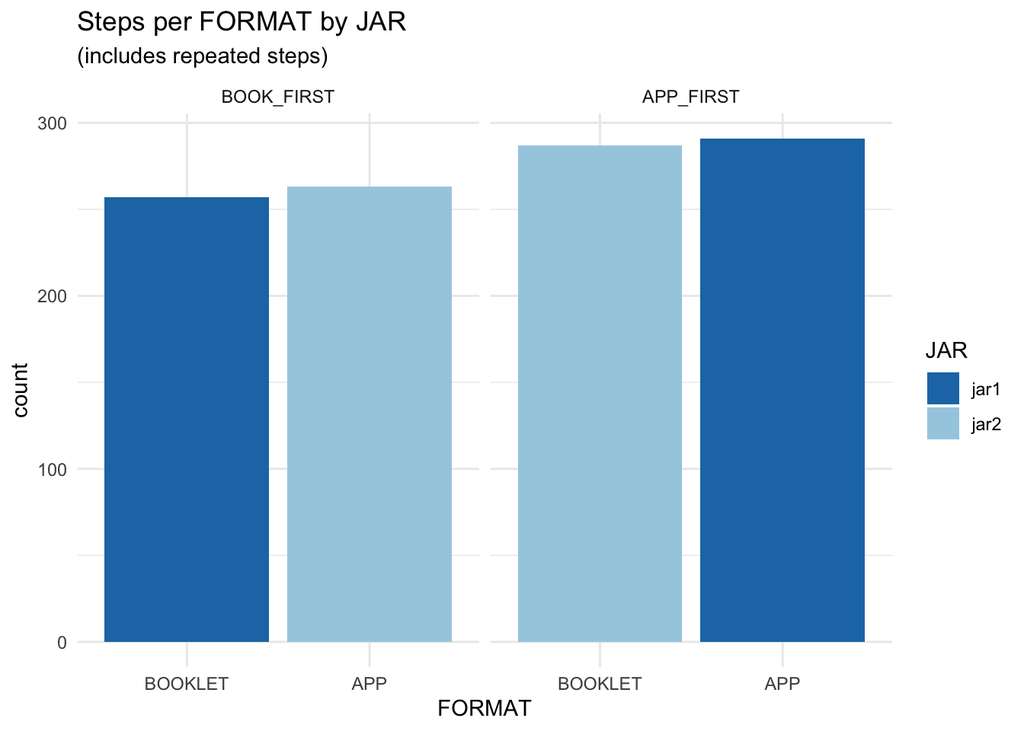

```r
## GROUPED BARCHART
##
df %>%
  ggplot(aes(x=FORMAT, fill=JAR))+
    geom_bar(position="dodge") +
   facet_wrap(~ORDER, scales = "free_x") +
  scale_fill_brewer(palette="Paired", direction =-1) +
  theme_minimal() +
  labs(title = "Steps per FORMAT by JAR",
       subtitle = "(includes repeated steps)")
```

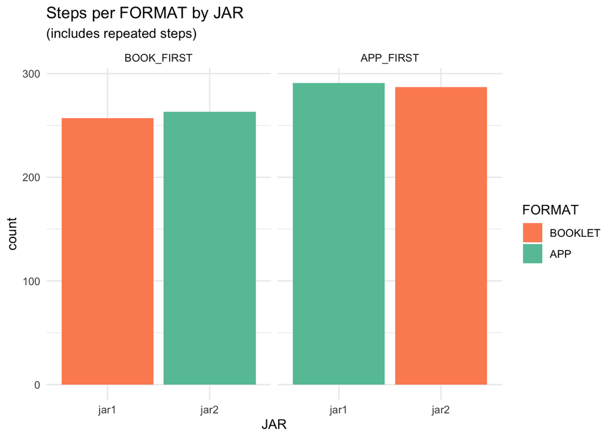

```r
## GROUPED BARCHART
##
df %>%
  ggplot(aes(x=JAR, fill=FORMAT))+
    geom_bar(position="dodge") +
   facet_wrap(~ORDER, scales = "free_x") +
      scale_fill_brewer(palette="Set2", direction =-1) +
  theme_minimal() +
  labs(title = "Steps per FORMAT by JAR",
       subtitle = "(includes repeated steps)")
```

#### TEST (jar-level) JAR

Is there a significant difference in number of steps PER JAR?

```r
## SET DATAFRAME
df <- df_steps_count %>%
  group_by(PID, JAR, FORMAT, ORDER) %>%
  dplyr::summarize( count = n())
```

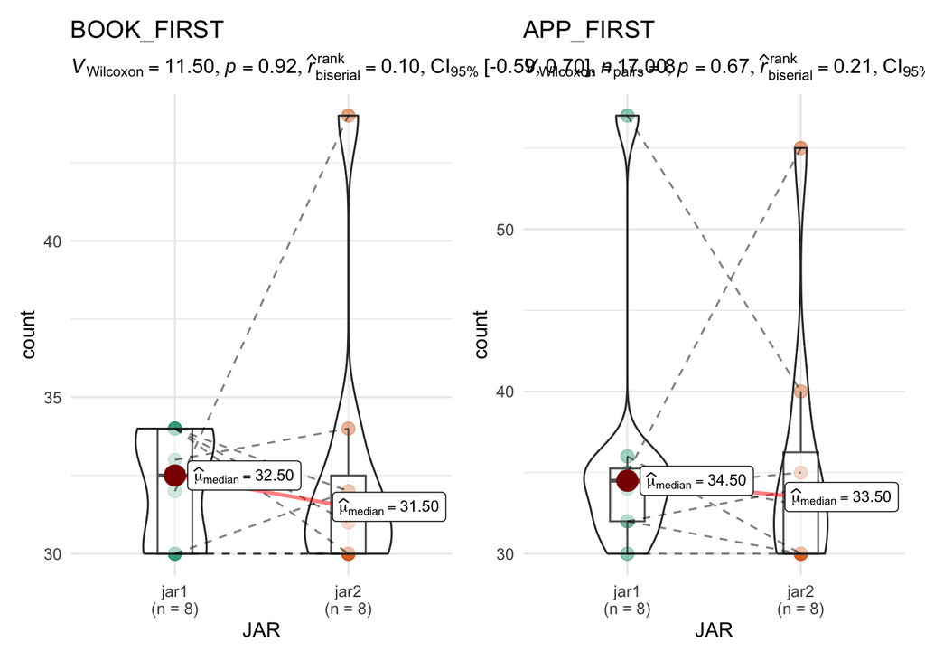

```r
## GGSTATSPLOT _ GROUPED WITHIN STATS
grouped_ggwithinstats(data = df,
              x = JAR, y = count,
              grouping.var = ORDER,
              by = PID,
              type= "nonparametric",
              results.subtitle = TRUE,
              bf.message = FALSE,
              ggtheme = ggplot2::theme_minimal())
```

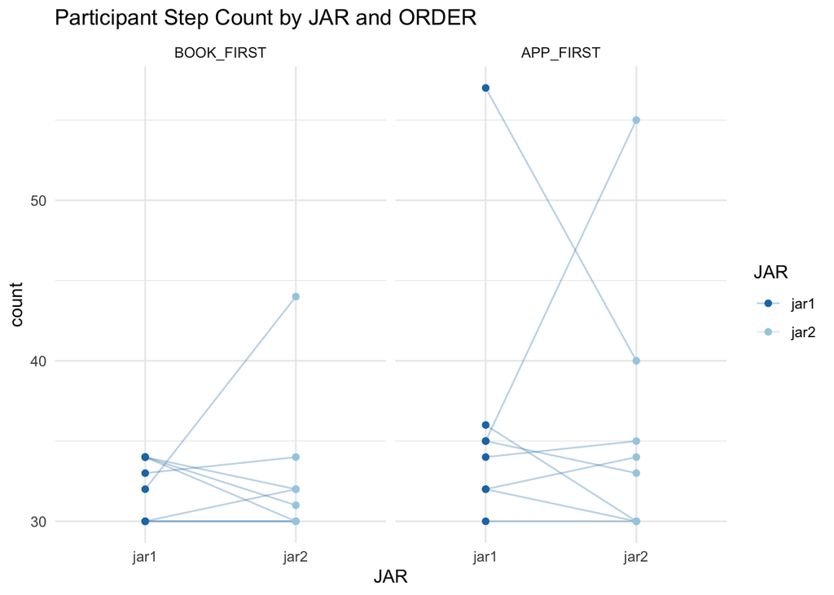

```r
## GGPLOT LINE GRAPH WITHIN SUBJECTS
df %>%
  ggplot(aes(JAR, count, group = PID, color=JAR)) +
  geom_line(alpha = .3) +
  scale_color_brewer(palette="Paired", direction =-1) +
  geom_point() +
  facet_wrap(~ORDER) +
  theme_minimal() +
  labs(title = "Participant Step Count by JAR and ORDER")
```

```r
## ANOVA
a <- aov_ez(
  id = "PID",
  dv = "count",
  within = c("JAR"),
  between = c("ORDER"),
  data = df
)
```

```
## Contrasts set to contr.sum for the following variables: ORDER
```

```r
summary(a)
```

```
##
## Univariate Type III Repeated-Measures ANOVA Assuming Sphericity
##
##             Sum Sq num Df Error SS den Df  F value    Pr(>F)
## (Intercept)  37675      1   737.75     14 714.9465 2.036e-13 ***
## ORDER          105      1   737.75     14   1.9949    0.1797
## JAR              0      1   454.75     14   0.0038    0.9514
## ORDER:JAR        3      1   454.75     14   0.0962    0.7610
## ---
## Signif. codes:  0 '***' 0.001 '**' 0.01 '*' 0.05 '.' 0.1 ' ' 1
```

#### TEST (jar-level) FORMAT

Is there a significant difference in number of steps PER FORMAT?

```r
## SET DATAFRAME
df <- df_steps_count %>%
  group_by(PID, JAR, FORMAT, ORDER) %>%
  dplyr::summarize( count = n())
```

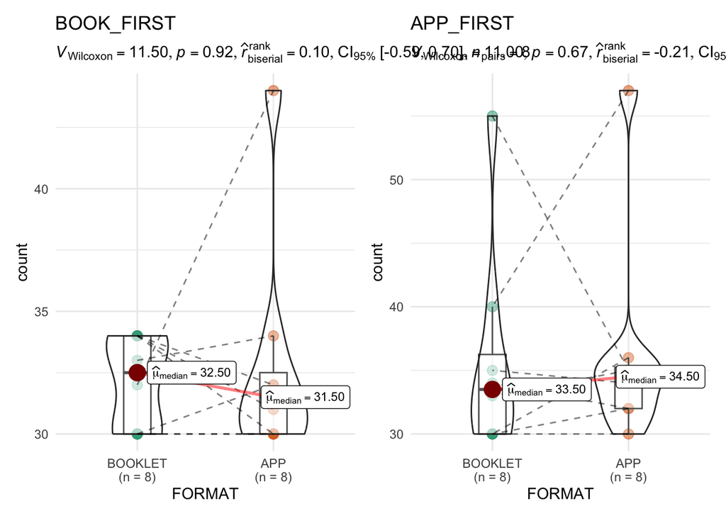

```r
## GGSTATSPLOT _ GROUPED WITHIN STATS
grouped_ggwithinstats(data = df,
              x = FORMAT, y = count,
              grouping.var = ORDER,
              by = PID,
              type= "nonparametric",
              results.subtitle = TRUE,
              bf.message = FALSE,
              ggtheme = ggplot2::theme_minimal())
```

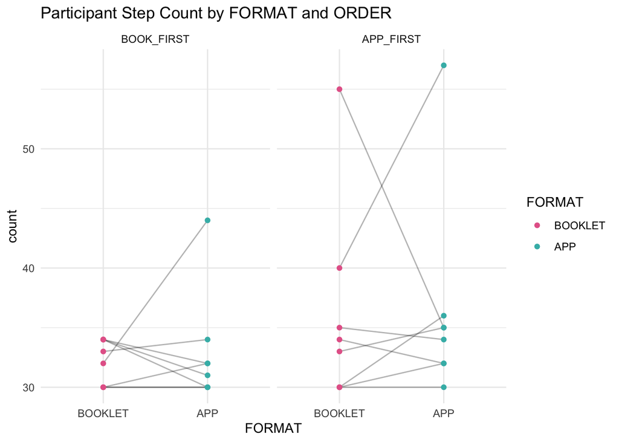

```r
## GGPLOT LINE GRAPH WITHIN SUBJECTS
df %>%
  ggplot(aes(FORMAT, count, group = PID, color=FORMAT)) +
  geom_line(alpha = .3, color="black") +
 scale_color_manual(values = format_pal) +
  geom_point() +
  facet_wrap(~ORDER) +
  theme_minimal() +
  labs(title = "Participant Step Count by FORMAT and ORDER")
```

```r
## ANOVA
a <- aov_ez(
  id = "PID",
  dv = "count",
  within = c("FORMAT"),
  between = c("ORDER"),
  data = df
)
```

```
## Contrasts set to contr.sum for the following variables: ORDER
```

```r
summary(a)
```

```
##
## Univariate Type III Repeated-Measures ANOVA Assuming Sphericity
##
##              Sum Sq num Df Error SS den Df  F value    Pr(>F)
## (Intercept)   37675      1   737.75     14 714.9465 2.036e-13 ***
## ORDER           105      1   737.75     14   1.9949    0.1797
## FORMAT            3      1   454.75     14   0.0962    0.7610
## ORDER:FORMAT      0      1   454.75     14   0.0038    0.9514
## ---
## Signif. codes:  0 '***' 0.001 '**' 0.01 '*' 0.05 '.' 0.1 ' ' 1
```

#### MODEL (participant level) STEP COUNT

What predicts number of steps per participant on each task?

```r
## SET DATAFRAME
df <- df_steps_count %>%
  group_by(PID, JAR, FORMAT, ORDER) %>%
  dplyr::summarize( count = n())
```

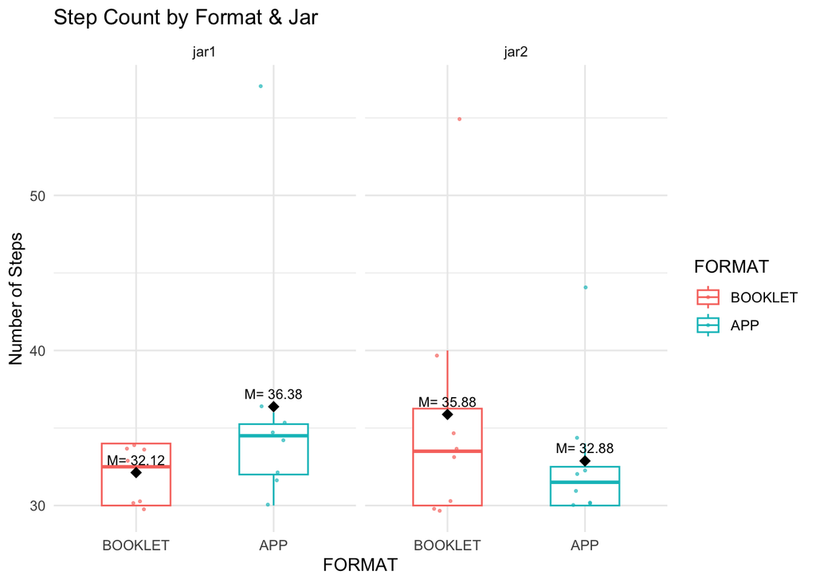

```r
## PLOT RAW DATA
## STRIP PLOT + MEAN LABEL
ggplot(df, aes(x = FORMAT, y = count, colour = FORMAT)) +
  geom_boxplot(
    aes(group = FORMAT),
    width = 0.5,
    outlier.shape = NA
  ) +
  geom_jitter(
    width = 0.1,
    alpha = 0.6,
    size = 0.5
  ) +
  # DISPLAY MEAN AS POINT
  stat_summary(
    fun = mean,
    geom = "point",
    shape = 18,
    size = 3,
    colour = "black"
  ) +
  # MEAN LABEL
  stat_summary(
    fun = mean,
    geom = "text",
    aes(label = paste("M=",sprintf("%.2f", after_stat(y)))),
    vjust = -0.8,
    colour = "black",
    size = 3
  ) +
  facet_wrap(~ JAR) +
  theme_minimal() +
  labs(title = "Step Count by Format & Jar",
       y = "Number of Steps")
```

```r
# ######## DROP OUTLINES
# ### DROP P10, P13
# df <- df |> filter(PID %nin% c("P10", "P13")) |> droplevels()
#
#
# ## PLOT RAW DATA
# ## STRIP PLOT + MEAN LABEL
# ggplot(df, aes(x = FORMAT, y = dur, colour = FORMAT)) +
#   geom_boxplot(
#     aes(group = FORMAT),
#     width = 0.5,
#     outlier.shape = NA
#   ) +
#   geom_jitter(
#     width = 0.1,
#     alpha = 0.6,
#     size = 0.5
#   ) +
#   # DISPLAY MEAN AS POINT
#   stat_summary(
#     fun = mean,
#     geom = "point",
#     shape = 18,
#     size = 3,
#     colour = "black"
#   ) +
#   # MEAN LABEL
#   stat_summary(
#     fun = mean,
#     geom = "text",
#     aes(label = paste("M=",sprintf("%.2f", after_stat(y)))),
#     vjust = -0.8,
#     colour = "black",
#     size = 3
#   ) +
#   facet_wrap(~ JAR) +
#   theme_minimal() +
#   labs(title = "Step Duration by Format & Jar",
#        y = "Duration (s)")
```

```r
## SET DATAFRAME
df <- df_steps_count %>%
  group_by(PID, JAR, FORMAT, ORDER) %>%
  dplyr::summarize( count = n())
## MODEL 1 | Simple Main Effects
m1 <- lmer(count ~ JAR * FORMAT + (1|PID), data = df)
summary(m1)
```

```
## Linear mixed model fit by REML. t-tests use Satterthwaite's method [
## lmerModLmerTest]
## Formula: count ~ JAR * FORMAT + (1 | PID)
##    Data: df
##
## REML criterion at convergence: 192
##
## Scaled residuals:
##      Min       1Q   Median       3Q      Max
## -0.83860 -0.39976 -0.20459  0.09719  2.78594
##
## Random effects:
##  Groups   Name        Variance Std.Dev.
##  PID      (Intercept) 10.11    3.179
##  Residual             32.48    5.699
## Number of obs: 32, groups:  PID, 16
##
## Fixed effects:
##                   Estimate Std. Error     df t value Pr(>|t|)
## (Intercept)         32.125      2.307 26.507  13.923 1.05e-13 ***
## JARjar2              3.750      3.263 26.507   1.149    0.261
## FORMATAPP            4.250      3.263 26.507   1.302    0.204
## JARjar2:FORMATAPP   -7.250      5.133 14.000  -1.412    0.180
## ---
## Signif. codes:  0 '***' 0.001 '**' 0.01 '*' 0.05 '.' 0.1 ' ' 1
##
## Correlation of Fixed Effects:
##             (Intr) JARjr2 FORMAT
## JARjar2     -0.707
## FORMATAPP   -0.707  0.619
## JAR2:FORMAT  0.556 -0.787 -0.787
```

```r
anova(m1)
```

```
## Type III Analysis of Variance Table with Satterthwaite's method
##            Sum Sq Mean Sq NumDF DenDF F value Pr(>F)
## JAR         0.125   0.125     1    14  0.0038 0.9514
## FORMAT      3.125   3.125     1    14  0.0962 0.7610
## JAR:FORMAT 64.799  64.799     1    14  1.9949 0.1797
```

```r
report(m1)
```

```
## We fitted a linear mixed model (estimated using REML and nloptwrap optimizer)
## to predict count with JAR and FORMAT (formula: count ~ JAR * FORMAT). The model
## included PID as random effect (formula: ~1 | PID). The model's total
## explanatory power is substantial (conditional R2 = 0.30) and the part related
## to the fixed effects alone (marginal R2) is of 0.08. The model's intercept,
## corresponding to JAR = jar1 and FORMAT = BOOKLET, is at 32.13 (95% CI [27.38,
## 36.87], t(26) = 13.92, p < .001). Within this model:
##
##   - The effect of JAR [jar2] is statistically non-significant and positive (beta
## = 3.75, 95% CI [-2.96, 10.46], t(26) = 1.15, p = 0.261; Std. beta = 0.58, 95%
## CI [-0.46, 1.61])
##   - The effect of FORMAT [APP] is statistically non-significant and positive
## (beta = 4.25, 95% CI [-2.46, 10.96], t(26) = 1.30, p = 0.204; Std. beta = 0.66,
## 95% CI [-0.38, 1.69])
##   - The effect of JAR [jar2] × FORMAT [APP] is statistically non-significant and
## negative (beta = -7.25, 95% CI [-17.80, 3.30], t(26) = -1.41, p = 0.170; Std.
## beta = -1.12, 95% CI [-2.75, 0.51])
##
## Standardized parameters were obtained by fitting the model on a standardized
## version of the dataset. 95% Confidence Intervals (CIs) and p-values were
## computed using a Wald t-distribution approximation.
```

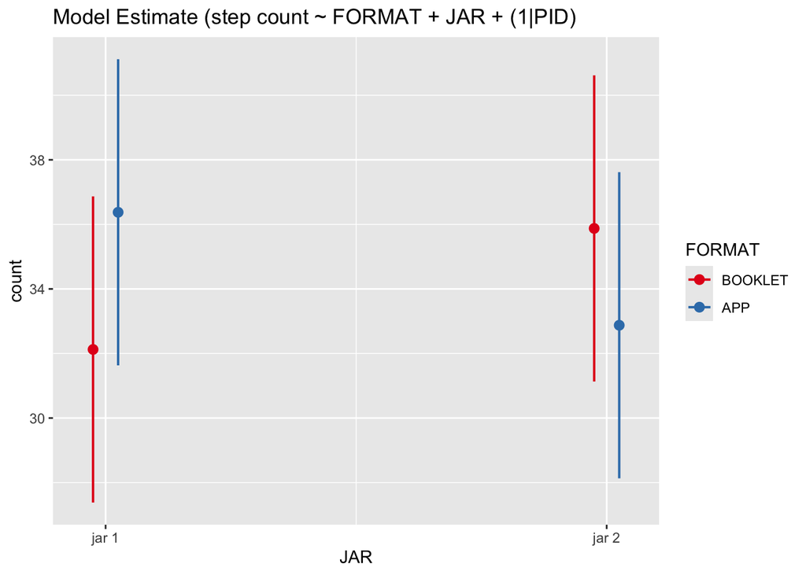

```r
## PLOT MODEL ESTIMATES
 plot_model(m1, show.values= TRUE, type = "int", title = "Model Estimate (step count ~ FORMAT + JAR + (1|PID)")
```

```r
## DESCRIBE MODEL VARIANCE EXPLAINED
v <- get_variance(m1)
t <- v$var.fixed + v$var.random + v$var.residual
fixed <- v$var.fixed/t * 100
random <- v$var.random/t * 100
residual <- v$var.residual/t * 100

## MODEL TABLE
m1_tab <- tidy(m1, effects = "fixed") %>%
  mutate(
    estimate  = round(estimate, 2),
    std.error = round(std.error, 2),
    statistic = round(statistic, 2),
    p.value   = ifelse(
      p.value < .001,
      "< .001",
      sprintf("= %.3f", p.value)
    )
  )
format_row <- filter(m1_tab, term == "FORMATAPP")
jar_row    <- filter(m1_tab, term == "JARjar2")
int_row    <- filter(m1_tab, term == "(Intercept)")
```

(reference level of FORMAT is BOOKLET; reference level of JAR is JAR1)

A linear mixed-effects model was fit to predict step COUNT from FORMAT and JAR, with a random intercept for participant (PID).

The effect of FORMAT was not statistically significant, β = 4.25, SE = 3.26, *t* = 1.3, *p* = 0.204.

The participant-level variance was 10.11 and the residual variance was 32.48.

*Fixed effects accounted for approximately 7.6% of the total variance, participant-level differences accounted for 21.9%, and 70.5% remained unexplained.*

### DURATION

#### DESCRIBE participant-level

```r
## SET DATAFRAME
df <- df_steps_duration %>%
  group_by(PID, JAR, FORMAT,ORDER) %>%
  summarise(
    total_duration = sum(as.numeric(DURATION), na.rm = TRUE),
    .groups = "drop"
  )

kable(df)
```

| PID | JAR | FORMAT | ORDER | total_duration |
| --- | --- | --- | --- | --- |
| P01 | jar1 | BOOKLET | BOOK_FIRST | 676.3 |
| P01 | jar2 | APP | BOOK_FIRST | 1379.2 |
| P02 | jar1 | BOOKLET | BOOK_FIRST | 831.5 |
| P02 | jar2 | APP | BOOK_FIRST | 980.3 |
| P03 | jar1 | APP | APP_FIRST | 1016.5 |
| P03 | jar2 | BOOKLET | APP_FIRST | 1164.8 |
| P04 | jar1 | APP | APP_FIRST | 818.3 |
| P04 | jar2 | BOOKLET | APP_FIRST | 1615.5 |
| P05 | jar1 | BOOKLET | BOOK_FIRST | 1208.2 |
| P05 | jar2 | APP | BOOK_FIRST | 1114.0 |
| P06 | jar1 | APP | APP_FIRST | 775.8 |
| P06 | jar2 | BOOKLET | APP_FIRST | 816.4 |
| P07 | jar1 | BOOKLET | BOOK_FIRST | 618.2 |
| P07 | jar2 | APP | BOOK_FIRST | 764.7 |
| P08 | jar1 | APP | APP_FIRST | 921.3 |
| P08 | jar2 | BOOKLET | APP_FIRST | 999.3 |
| P09 | jar1 | BOOKLET | BOOK_FIRST | 1069.2 |
| P09 | jar2 | APP | BOOK_FIRST | 907.3 |
| P10 | jar1 | BOOKLET | BOOK_FIRST | 869.1 |
| P10 | jar2 | APP | BOOK_FIRST | 1461.3 |
| P12 | jar1 | BOOKLET | BOOK_FIRST | 997.1 |
| P12 | jar2 | APP | BOOK_FIRST | 984.8 |
| P13 | jar1 | APP | APP_FIRST | 567.0 |
| P13 | jar2 | BOOKLET | APP_FIRST | 946.4 |
| P14 | jar1 | APP | APP_FIRST | 665.3 |
| P14 | jar2 | BOOKLET | APP_FIRST | 677.9 |
| P15 | jar1 | BOOKLET | BOOK_FIRST | 524.6 |
| P15 | jar2 | APP | BOOK_FIRST | 668.2 |
| P16 | jar1 | APP | APP_FIRST | 489.8 |
| P16 | jar2 | BOOKLET | APP_FIRST | 559.4 |
| P17 | jar1 | APP | APP_FIRST | 1287.3 |
| P17 | jar2 | BOOKLET | APP_FIRST | 1634.8 |

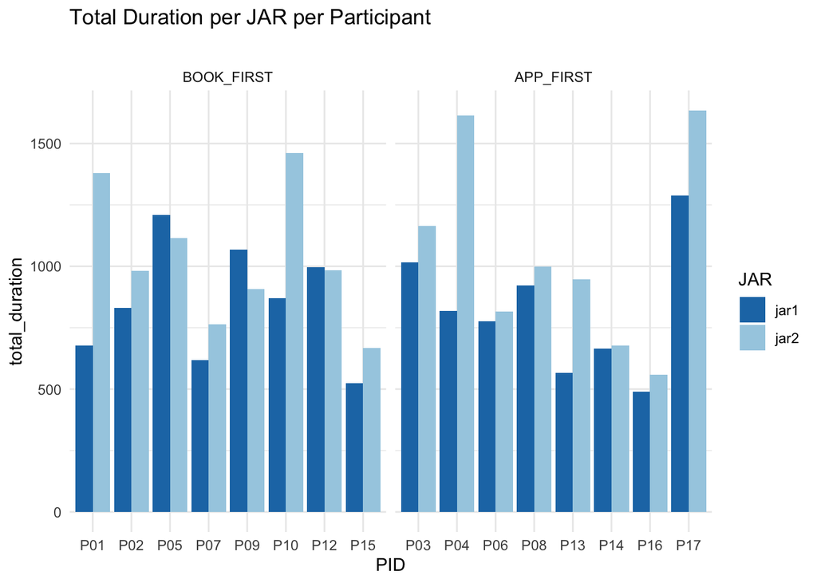

```r
## GROUPED BARCHART
df %>%
  ggplot(aes(x=PID, y=total_duration,  fill=JAR))+
      geom_col(position = "dodge") +
  facet_wrap(~ORDER, scales = "free_x") +
  scale_fill_brewer(palette="Paired", direction =-1) +
  theme_minimal() +
  labs(title = "Total Duration per JAR per Participant",
       subtitle = "")
```

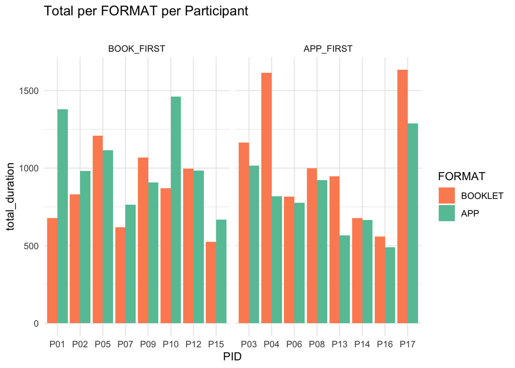

```r
## GROUPED BARCHART
df %>%
  ggplot(aes(x=PID, y=total_duration, fill=FORMAT))+
    geom_col(position="dodge") +
   facet_wrap(~ORDER, scales = "free_x") +
    scale_fill_brewer(palette="Set2", direction =-1) +
  theme_minimal() +
  labs(title = "Total per FORMAT per Participant",
       subtitle = "")
```

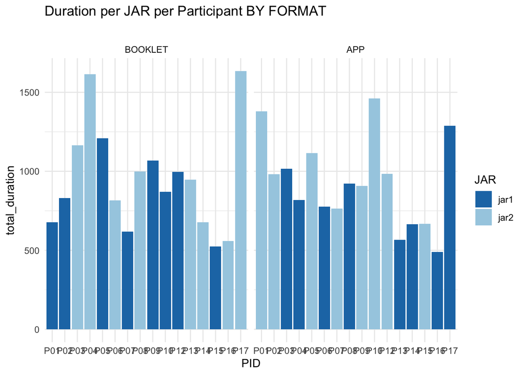

```r
## GROUPED BARCHART [COUNT STEPS X PARTICIPANT by JAR facet FORMAT]
g <- df %>%
  ggplot(aes(x=PID, y=total_duration, fill=JAR))+
    geom_col(position="dodge") +
  scale_fill_brewer(palette="Paired", direction =-1) +
  facet_wrap(~FORMAT) +
  theme_minimal() +
  labs(title = "Duration per JAR per Participant BY FORMAT",
       subtitle = "")

g
```

```r
ggsave(
  filename = "figs/step_duration_by_format.svg",
  plot = g,
  device = svglite,
  width = 6,
  height = 4,
  units = "in"
)
```

#### DESCRIBE jar-level

```r
## SET DATAFRAME
df <- df_duration_by_particiapnt <- df_steps_duration |>
  group_by(PID,JAR,FORMAT,ORDER) |>
  summarise(
    DURATION = sum(DURATION)
 )
```

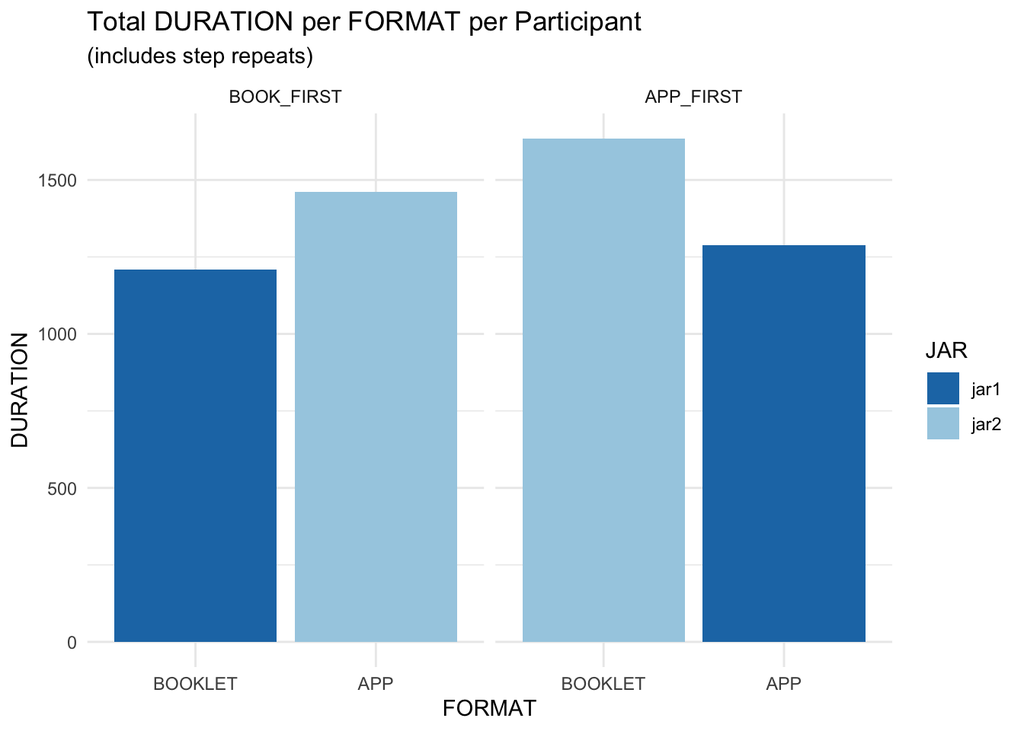

```r
## GROUPED BARCHART by JAR
df %>%
    ggplot(aes(fill=JAR))+
    scale_fill_brewer(palette="Paired", direction =-1) +
    geom_bar(aes(x=FORMAT, y= DURATION), position="dodge", stat="identity") +
  facet_wrap(~ORDER) +
  theme_minimal() +
  labs(title = "Total DURATION per FORMAT per Participant",
       subtitle = "(includes step repeats)")
```

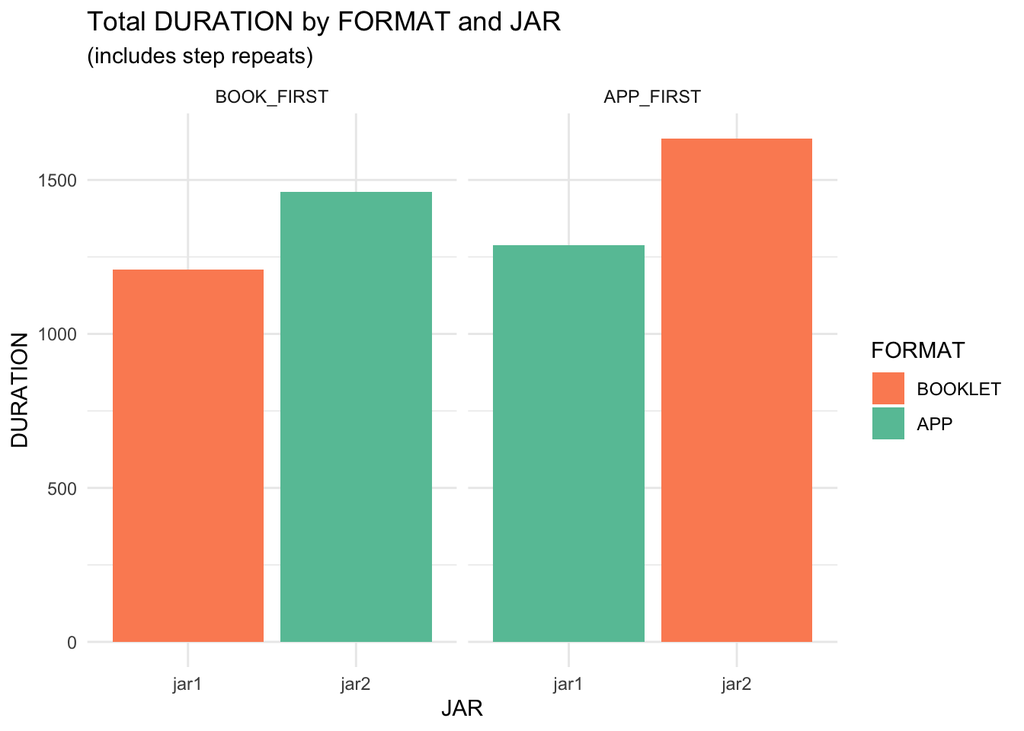

```r
## GROUPED BARCHART by FORMAT
df %>%
    ggplot(aes(fill=FORMAT))+
    scale_fill_brewer(palette="Set2", direction =-1) +
    geom_bar(aes(x=JAR, y= DURATION), position="dodge", stat="identity") +
  facet_wrap(~ORDER) +
  theme_minimal() +
  labs(title = "Total DURATION by FORMAT and JAR",
       subtitle = "(includes step repeats)")
```

#### TEST (jar-level) JAR – the one with the plots

Is there a significant difference in duration of steps PER JAR?

```r
## SET DATAFRAME
df <- df_steps_duration %>%
  group_by(PID, JAR, FORMAT, ORDER) %>%
  dplyr::summarize( time = as.double(sum(DURATION)))
```

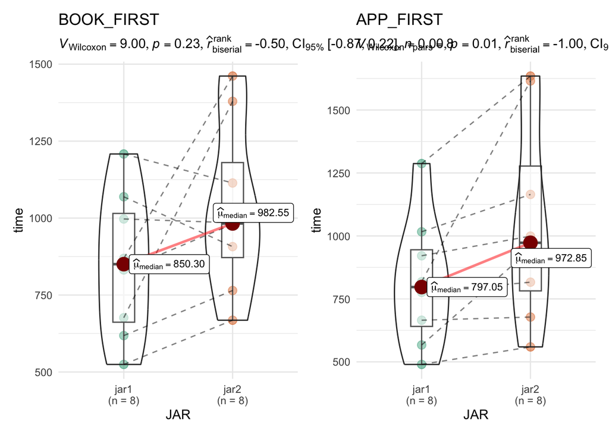

```r
## GGSTATSPLOT _ GROUPED WITHIN STATS
grouped_ggwithinstats(data = df,
              x = JAR, y = time,
              grouping.var = ORDER,
              by = PID,
              type= "nonparametric",
              results.subtitle = TRUE,
              bf.message = FALSE,
              ggtheme = ggplot2::theme_minimal())
```

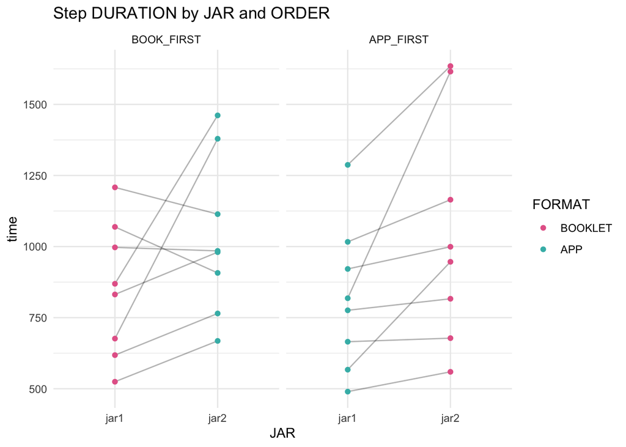

```r
## GGPLOT LINE GRAPH WITHIN SUBJECTS
g <- df %>%
  ggplot(aes(JAR, time, group = PID, color=FORMAT)) +
  geom_line(alpha = .3, color = "black") +
  # scale_color_brewer(palette="Paired", direction =-1) +
    scale_color_manual(values = format_pal) +

  geom_point() +
  facet_wrap(~ORDER) +
  theme_minimal() +
  labs(title = "Step DURATION by JAR and ORDER")

g
```

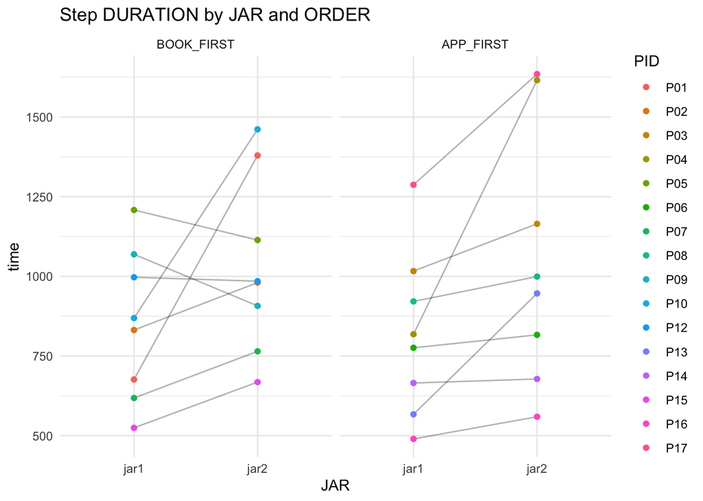

```r
ggsave(
  filename = "figs/linegraph_duration_jar.svg",
  plot = g,
  device = svglite,
  width = 8,
  height = 6,
  units = "in"
)


## GGPLOT LINE GRAPH WITHIN SUBJECTS
g <- df %>%
  ggplot(aes(JAR, time, group = PID, color=PID)) +
  geom_line(alpha = .3, color = "black") +
  geom_point() +
  facet_wrap(~ORDER) +
  theme_minimal() +
  labs(title = "Step DURATION by JAR and ORDER")

g
```

```r
ggsave(
  filename = "figs/linegraph_duration_PID.svg",
  plot = g,
  device = svglite,
  width = 8,
  height = 6,
  units = "in"
)


## ANOVA
a <- aov_ez(
  id = "PID",
  dv = "time",
  within = c("JAR"),
  between = c("ORDER"),
  data = df
)
```

```
## Contrasts set to contr.sum for the following variables: ORDER
```

```r
summary(a)
```

```
##
## Univariate Type III Repeated-Measures ANOVA Assuming Sphericity
##
##               Sum Sq num Df Error SS den Df  F value    Pr(>F)
## (Intercept) 28143378      1  1926347     14 204.5360 9.548e-10 ***
## ORDER            301      1  1926347     14   0.0022    0.9633
## JAR           348362      1   586040     14   8.3221    0.0120 *
## ORDER:JAR       5192      1   586040     14   0.1240    0.7300
## ---
## Signif. codes:  0 '***' 0.001 '**' 0.01 '*' 0.05 '.' 0.1 ' ' 1
```

#### TEST (jar-level) FORMAT

Is there a significant difference in duration of steps PER FORMAT?

```r
## SET DATAFRAME
df <- df_steps_duration %>%
  group_by(PID, JAR, FORMAT, ORDER) %>%
  dplyr::summarize( time = as.double(sum(DURATION)))
```

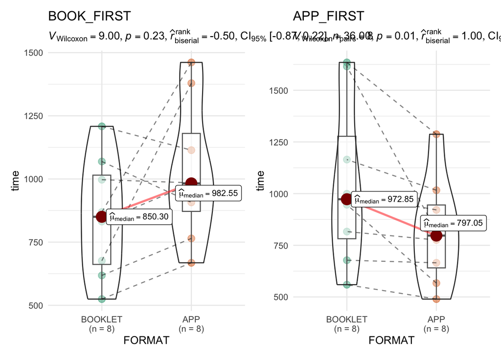

```r
## GGSTATSPLOT _ GROUPED WITHIN STATS
grouped_ggwithinstats(data = df,
              x = FORMAT, y = time,
              grouping.var = ORDER,
              by = PID,
              type= "nonparametric",
              results.subtitle = TRUE,
              bf.message = FALSE,
              ggtheme = ggplot2::theme_minimal())
```

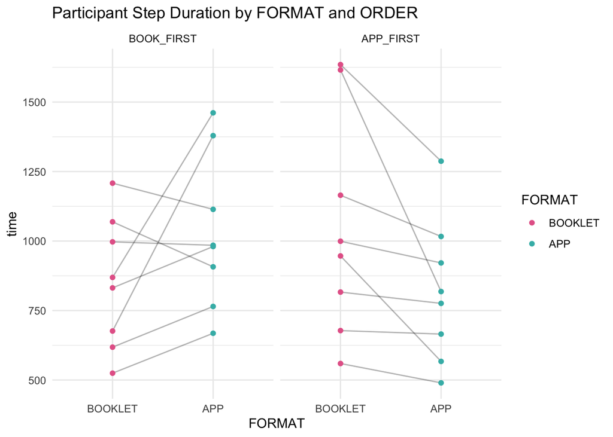

```r
## GGPLOT LINE GRAPH WITHIN SUBJECTS
df %>%
  ggplot(aes(FORMAT, time, group = PID, color=FORMAT)) +
  geom_line(alpha = .3, color="black") +
  scale_color_manual(values = format_pal) +
  geom_point() +
  facet_wrap(~ORDER) +
  theme_minimal() +
  labs(title = "Participant Step Duration by FORMAT and ORDER")
```

```r
## ANOVA
a <- aov_ez(
  id = "PID",
  dv = "time",
  within = c("FORMAT"),
  between = c("ORDER"),
  data = df
)
```

```
## Contrasts set to contr.sum for the following variables: ORDER
```

```r
summary(a)
```

```
##
## Univariate Type III Repeated-Measures ANOVA Assuming Sphericity
##
##                Sum Sq num Df Error SS den Df  F value    Pr(>F)
## (Intercept)  28143378      1  1926347     14 204.5360 9.548e-10 ***
## ORDER             301      1  1926347     14   0.0022    0.9633
## FORMAT           5192      1   586040     14   0.1240    0.7300
## ORDER:FORMAT   348362      1   586040     14   8.3221    0.0120 *
## ---
## Signif. codes:  0 '***' 0.001 '**' 0.01 '*' 0.05 '.' 0.1 ' ' 1
```

## SPEED-ACCURACY

### DESCRIBE Jar-level

What is the relationship between a participant’s speed and accuracy on the tasks?

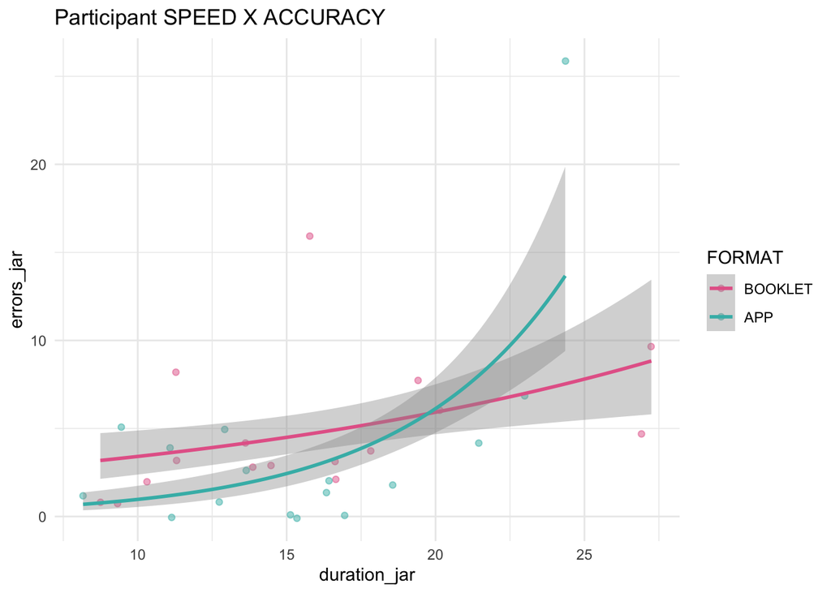

```r
## SET DATAFRAME
df <- df_tiny_task


## SCATTERPLOT
g <- df %>% ggplot(aes(x= duration_jar, y = errors_jar, color=FORMAT)) +
  geom_jitter(alpha=0.5) +
  scale_color_manual(values = format_pal) +
  # geom_smooth(method = "lm", se = TRUE) + # linear regression
  geom_smooth(
  method = "glm",
  method.args = list(family = poisson),
  se = TRUE
 ) +
  # facet_wrap(~JAR) +
  theme_minimal() +
  labs(title = "Participant SPEED X ACCURACY")

g
```

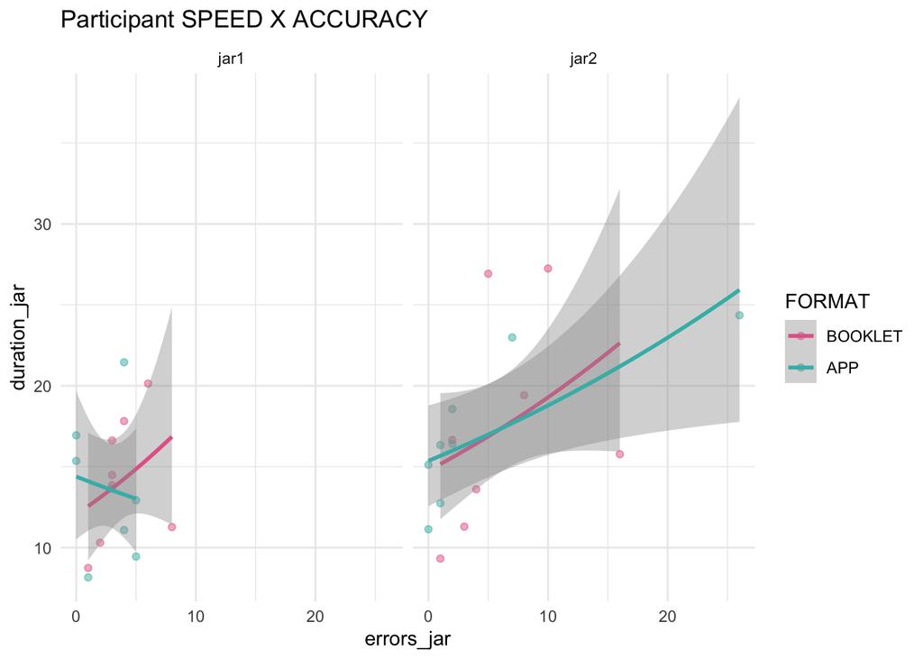

```r
ggsave(
  filename = "figs/speed_accuracy_JAR.svg",
  plot = g,
  device = svglite,
  width = 6,
  height = 4,
  units = "in"
)
## SCATTERPLOT
df %>% ggplot(aes(x= errors_jar, y = duration_jar, color=FORMAT)) +
  geom_point(alpha=0.5) +
   # geom_smooth(method = "lm", se = TRUE) + # linear regression
  geom_smooth(
  method = "glm",
  method.args = list(family = poisson),
  se = TRUE
 ) +
  scale_color_manual(values = format_pal) +
  facet_wrap(~JAR) +
  theme_minimal() +
  labs(title = "Participant SPEED X ACCURACY")
```

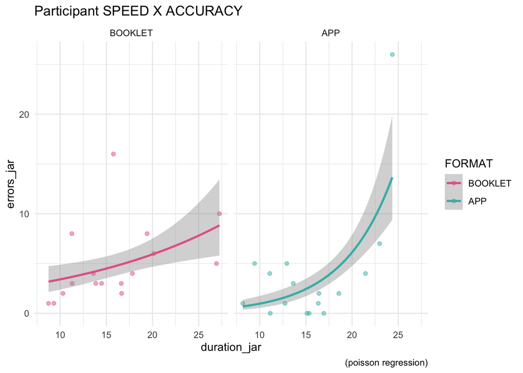

```r
## SCATTERPLOT
g <- df %>% ggplot(aes(x= duration_jar, y = errors_jar, color=FORMAT)) +
  geom_point(alpha=0.5) +
  scale_color_manual(values = format_pal) +
   # geom_smooth(method = "lm", se = TRUE) + # linear regression
  geom_smooth(
  method = "glm",
  method.args = list(family = poisson),
  se = TRUE
 ) +
  facet_wrap(~FORMAT) +
  theme_minimal() +
  labs(title = "Participant SPEED X ACCURACY",
       caption="(poisson regression)")

g
```

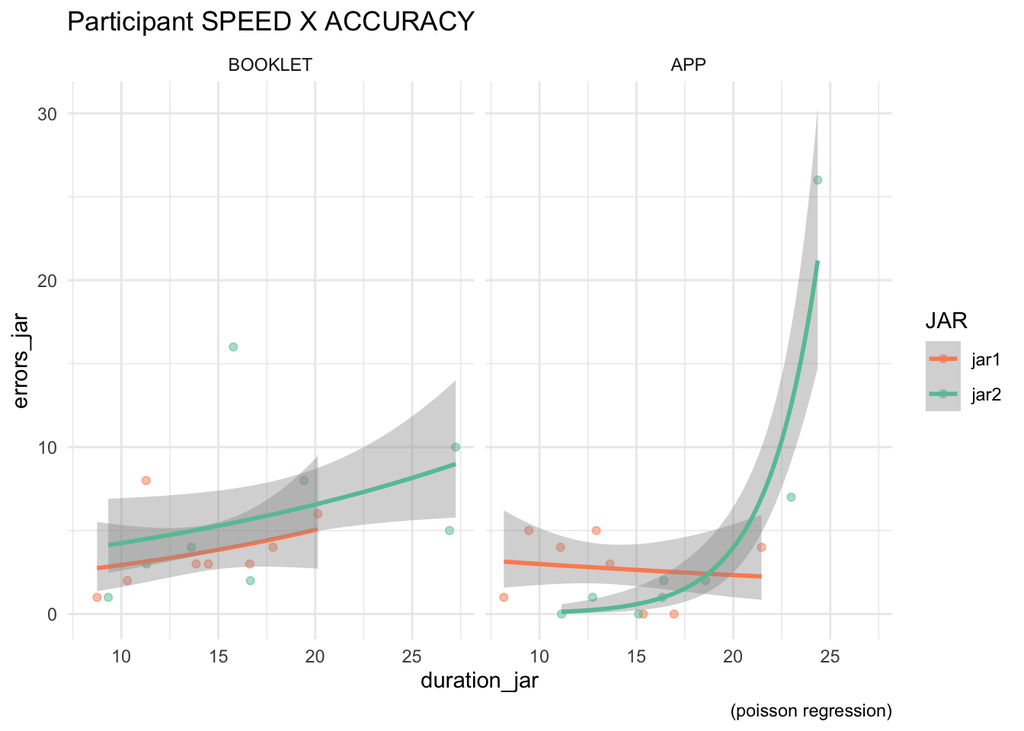

```r
ggsave(
  filename = "figs/speed_accuracy_FORMAT_FACET.svg",
  plot = g,
  device = svglite,
  width = 6,
  height = 4,
  units = "in"
)
## SCATTERPLOT
g <- df %>% ggplot(aes(x= duration_jar, y = errors_jar, color=JAR)) +
  geom_point(alpha=0.5) +
  scale_color_brewer(palette="Set2", direction =-1) +
   # geom_smooth(method = "lm", se = TRUE) + # linear regression
  geom_smooth(
  method = "glm",
  method.args = list(family = poisson),
  se = TRUE
 ) +
  facet_wrap(~FORMAT) +
  theme_minimal() +
  labs(title = "Participant SPEED X ACCURACY",
       caption="(poisson regression)")

g
```

```r
ggsave(
  filename = "figs/speed_accuracy_JAR_FORMAT_FACET.svg",
  plot = g,
  device = svglite,
  width = 6,
  height = 4,
  units = "in"
)
```

### MODEL Jar-level

```r
df <- df_tasks

m1 <- lmer(duration_jar ~ errors_jar + FORMAT + JAR + (1|PID), data = df)
summary(m1)
```

```
## Linear mixed model fit by REML. t-tests use Satterthwaite's method [
## lmerModLmerTest]
## Formula: duration_jar ~ errors_jar + FORMAT + JAR + (1 | PID)
##    Data: df
##
## REML criterion at convergence: 173.2
##
## Scaled residuals:
##     Min      1Q  Median      3Q     Max
## -1.5347 -0.4479 -0.2111  0.5234  2.1174
##
## Random effects:
##  Groups   Name        Variance Std.Dev.
##  PID      (Intercept) 10.579   3.253
##  Residual              9.124   3.021
## Number of obs: 32, groups:  PID, 16
##
## Fixed effects:
##              Estimate Std. Error        df t value Pr(>|t|)
## (Intercept) 1.266e+01  1.339e+00 2.779e+01   9.460 3.48e-10 ***
## errors_jar  3.775e-01  1.377e-01 2.241e+01   2.741   0.0118 *
## FORMATAPP   8.720e-05  1.079e+00 1.357e+01   0.000   0.9999
## JARjar2     2.629e+00  1.112e+00 1.400e+01   2.364   0.0331 *
## ---
## Signif. codes:  0 '***' 0.001 '**' 0.01 '*' 0.05 '.' 0.1 ' ' 1
##
## Correlation of Fixed Effects:
##            (Intr) errrs_ FORMAT
## errors_jar -0.392
## FORMATAPP  -0.451  0.144
## JARjar2    -0.274 -0.279 -0.040
```

```r
report(m1)
```

```
## We fitted a linear mixed model (estimated using REML and nloptwrap optimizer)
## to predict duration_jar with errors_jar, FORMAT and JAR (formula: duration_jar
## ~ errors_jar + FORMAT + JAR). The model included PID as random effect (formula:
## ~1 | PID). The model's total explanatory power is substantial (conditional R2 =
## 0.66) and the part related to the fixed effects alone (marginal R2) is of 0.26.
## The model's intercept, corresponding to errors_jar = 0, FORMAT = BOOKLET and
## JAR = jar1, is at 12.66 (95% CI [9.91, 15.42], t(26) = 9.46, p < .001). Within
## this model:
##
##   - The effect of errors jar is statistically significant and positive (beta =
## 0.38, 95% CI [0.09, 0.66], t(26) = 2.74, p = 0.011; Std. beta = 0.39, 95% CI
## [0.10, 0.68])
##   - The effect of FORMAT [APP] is statistically non-significant and positive
## (beta = 8.72e-05, 95% CI [-2.22, 2.22], t(26) = 8.08e-05, p > .999; Std. beta =
## 1.72e-05, 95% CI [-0.44, 0.44])
##   - The effect of JAR [jar2] is statistically significant and positive (beta =
## 2.63, 95% CI [0.34, 4.91], t(26) = 2.36, p = 0.026; Std. beta = 0.52, 95% CI
## [0.07, 0.97])
##
## Standardized parameters were obtained by fitting the model on a standardized
## version of the dataset. 95% Confidence Intervals (CIs) and p-values were
## computed using a Wald t-distribution approximation.
```

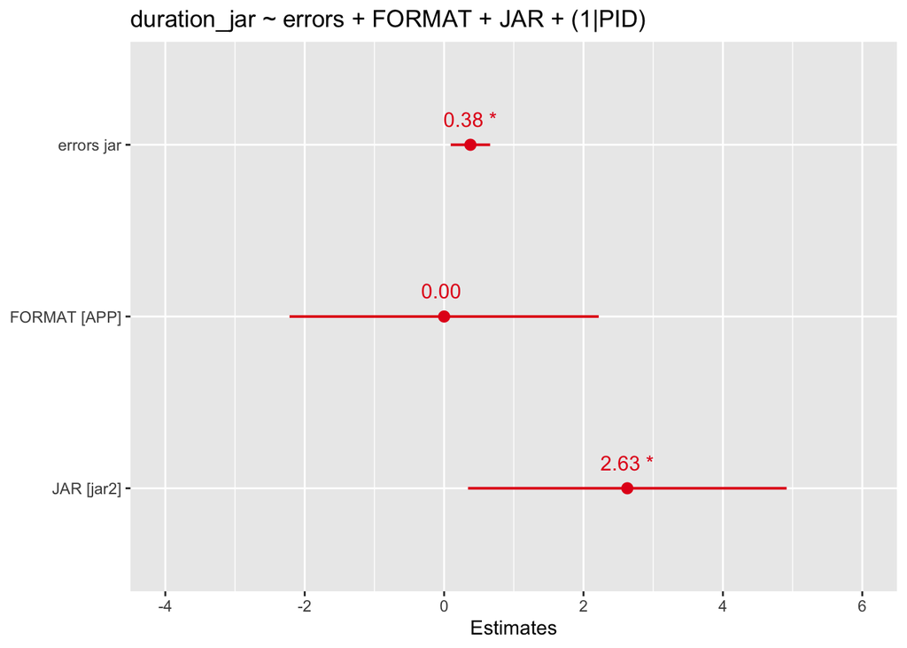

```r
plot_model(m1, type="est", show.values = TRUE, show.p = TRUE, title = "duration_jar ~ errors + FORMAT + JAR + (1|PID)")
```

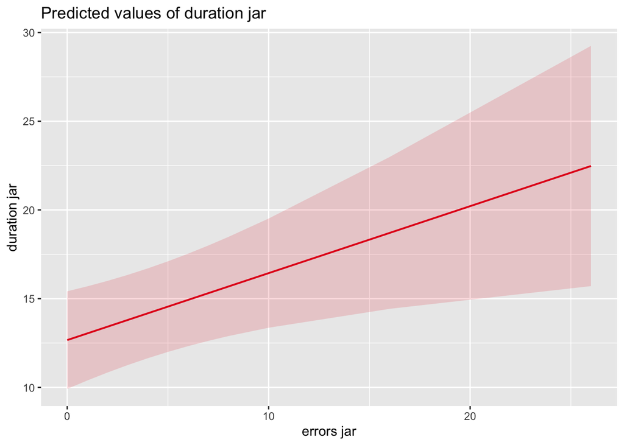

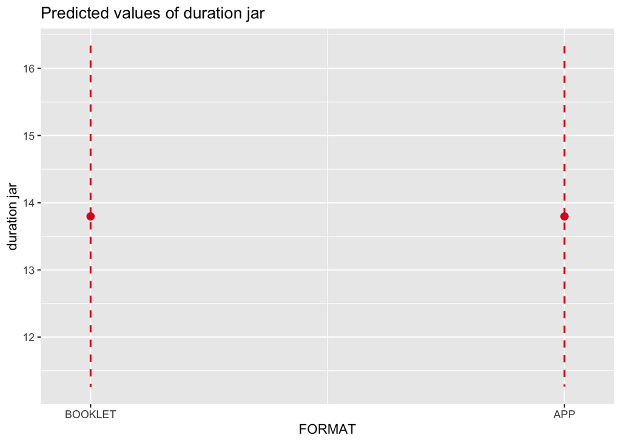

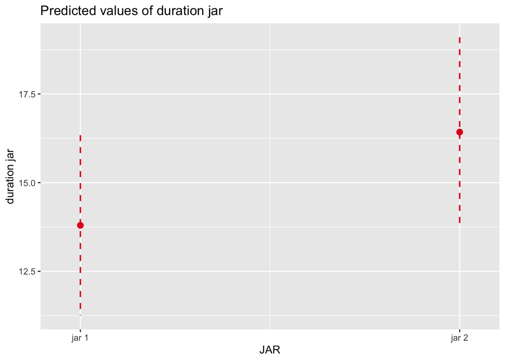

```r
plot_model(m1, type = "pred")
```

### WIP JOIN STEP DURATION - ERRORS

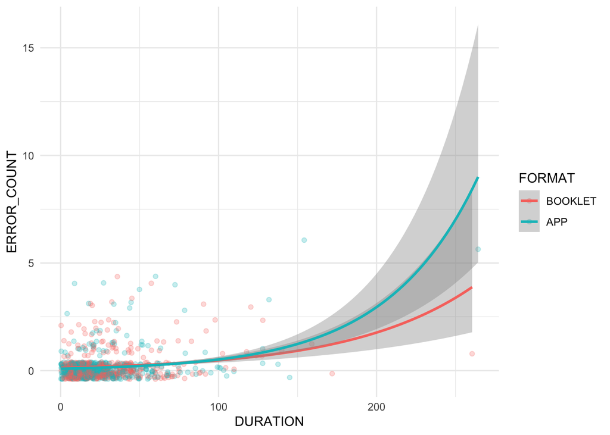

```r
df <- df_joined_steps_errors

df |> ggplot(aes(x= DURATION, y=ERROR_COUNT, color=FORMAT)) +
  geom_jitter(alpha = 0.25) +
  # facet_grid(COMPLEXITY~JAR) +
  geom_smooth(
    method = "glm",
    method.args = list(family = poisson),
    se = TRUE
  ) +
  theme_minimal()
```

## STASH

```r
## REFERENCE CONDITIONAL MUTATE SYNTAX
 # mutate(grade = case_when(
 #    score >= 90 ~ "A",
 #    score >= 80 ~ "B",
 #    TRUE ~ "C"  # Default value
 #  ))
```